# Detecting Year-to-Year Change in Plant Cover: Baseline and Sample-Size Sensitivity Using NEON Data

Dave Barnett, Courtney Meier, and Eric Sokole

August 11, 2025

# 1 1 Introduction

NEON’s plant diversity program was designed to support detection of biologically meaningful change across space and time. Earlier optimization focused mainly on **spatial** trade-offs. With longer time series now available, we extend that work into the **temporal** domain and ask two operational questions:

1. **How well are we doing now?** For each site and year pair, what is our current probability of detecting interannual change in species cover, given the plots we actually sampled (the **baseline**)?
2. **Can we do as well with fewer plots?** Using a **sample-size sensitivity** analysis, can reduced effort approach the baseline—pair by pair—without undermining detection?

We fit a Bayesian joint species model (GJAM), propagate posterior uncertainty to species- and community-level summaries, and compare **baseline** performance with **variable-K** scenarios that let each year pair use up to the plots it actually has.

# 2 2 Methods

## 2.1 2.1 Data and response

We used NEON’s Plant presence and percent cover (DP1.10058.001), aggregated to plot × year × species. **Relative cover** is species cover divided by total cover within a plot–year and provides weights for community aggregation.

## 2.2 2.2 Model

We fit GJAM (`fit_gjam_model_test`) with the formula

```r
~ year + nlcdClass
```

- **year** is a **factor**, enabling direct year-pair contrasts without imposing linear trends.
- **nlcdClass** accounts for coarse habitat differences; even if not summarized later, it absorbs variance unrelated to interannual change, improving power.

All species use the `CA` family. MCMC settings follow your `fit_gjam_model_test()` defaults.

## 2.3 2.3 Posterior predictions and detection

For each year pair, we simulate baseline vs. changed years from the posterior and compute species-level detection probability as the posterior mass above a threshold on the difference (changed − baseline). We retain posterior means and 95% credible intervals from draws.

## 2.4 2.4 Sample-size sensitivity (variable by pair) and baseline

For a requested size $K$, each pair uses $k=\min(K, n_{\text{available}}(\text{pair}))$. We also compute a **baseline** per pair with $k=n_{\text{available}}(\text{pair})$, showing the best achievable detection with current coverage.

## 2.6 2.6 Decision summary

For each $K$, we report the **fraction of year pairs** whose CWM detection meets or exceeds 0.8. This provides a clear, site-specific adequacy criterion without jargon.

# 3 3 Results

## 3.1 3.1 Species-level detection (example site) — variable curves, baseline overlay when available

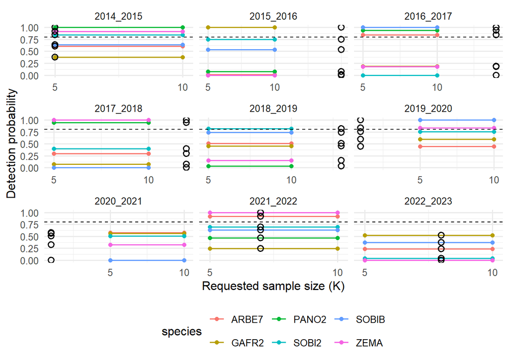

## 3.2 3.2 Posterior distribution example (real draws if available)

[figure not shown]

## 3.3 3.3 Community-weighted detection by year pair (example site)

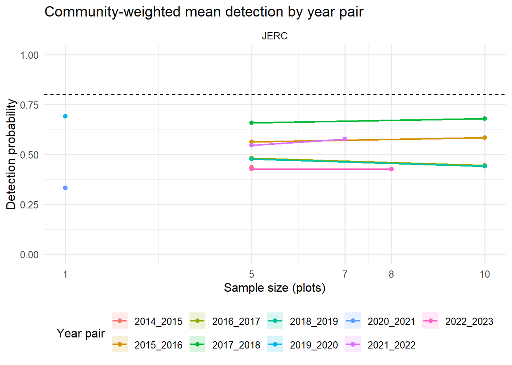

Figure 3.3: Figure 3. Community-weighted detection by year pair (variable mode) at the example site.

## 3.4 3.4 Mean across year pairs (example site)

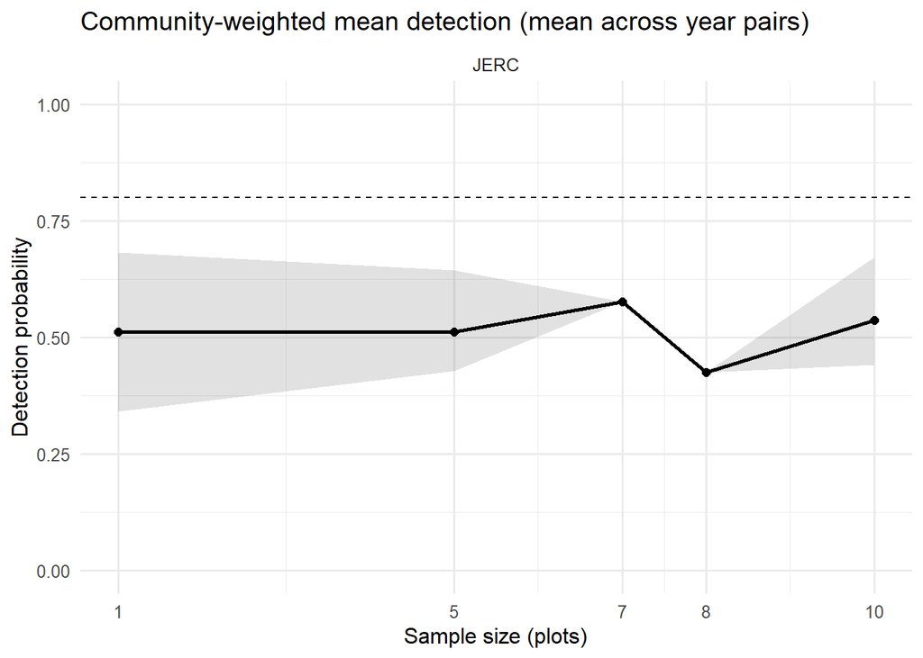

Figure 3.4: Figure 4. Mean community-weighted detection across year pairs (variable mode) at the example site.

## 3.5 3.5 Site-level decision summary (variable mode)

Table 3.1: Table 1. Fraction of year pairs meeting the 0.8 detection threshold by requested sample size.

| requested_sample_size | frac_pairs_meeting_threshold |
| --- | --- |
| 5 | 0 |
| 10 | 0 |

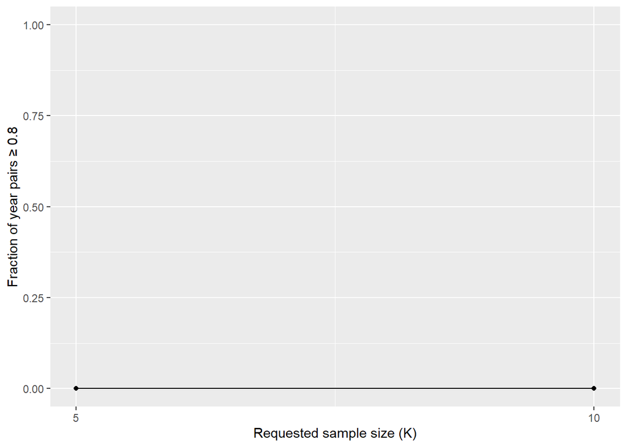

Figure 3.5: Figure 5. Fraction of year pairs meeting the 0.8 detection threshold by requested sample size (variable mode).

# 4 4 Discussion

**Current status and headroom.** Baseline overlays show how well the existing plot network detects interannual change given current coverage. Variable-K curves indicate how close reduced effort comes to that upper bound.  
**From species to community.** Species signals are heterogeneous; weighting by relative cover yields clear, aggregated community detection while keeping uncertainty explicit.  
**Why include `nlcdClass`.** Including land-cover class during fitting absorbs background habitat differences and increases sensitivity to year-to-year change.  
**Clear decision language.** We report the fraction of year pairs meeting a pre-specified detection criterion (0.8). This is transparent and site-specific.

# Appendix

## 4.1 A.1 All sites: CWM detection by year pair

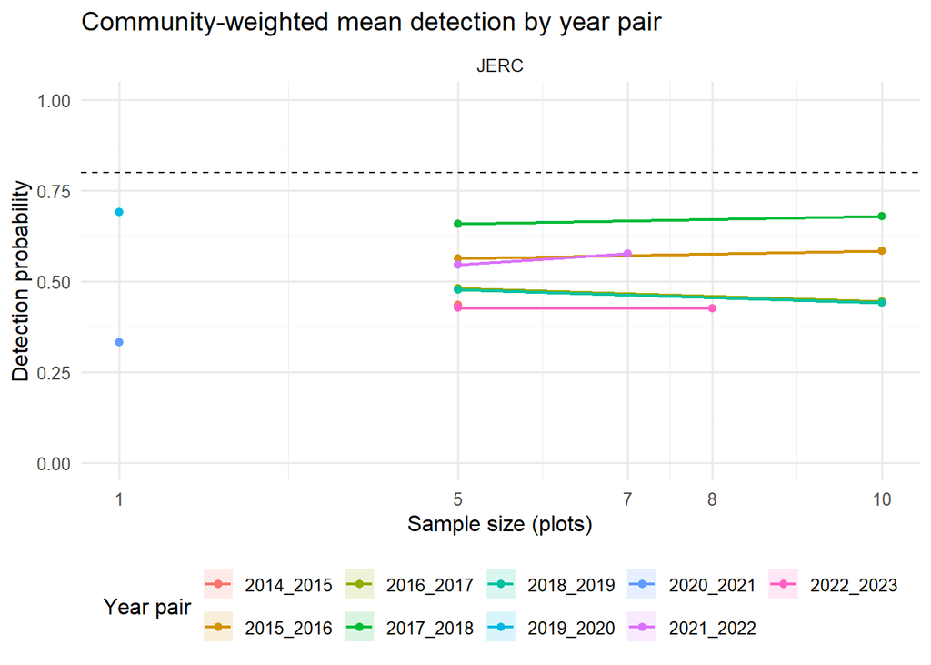

Figure 4.1: Figure A1. Community-weighted detection by year pair for all sites (variable mode).

## 4.2 A.2 All sites: Mean across year pairs

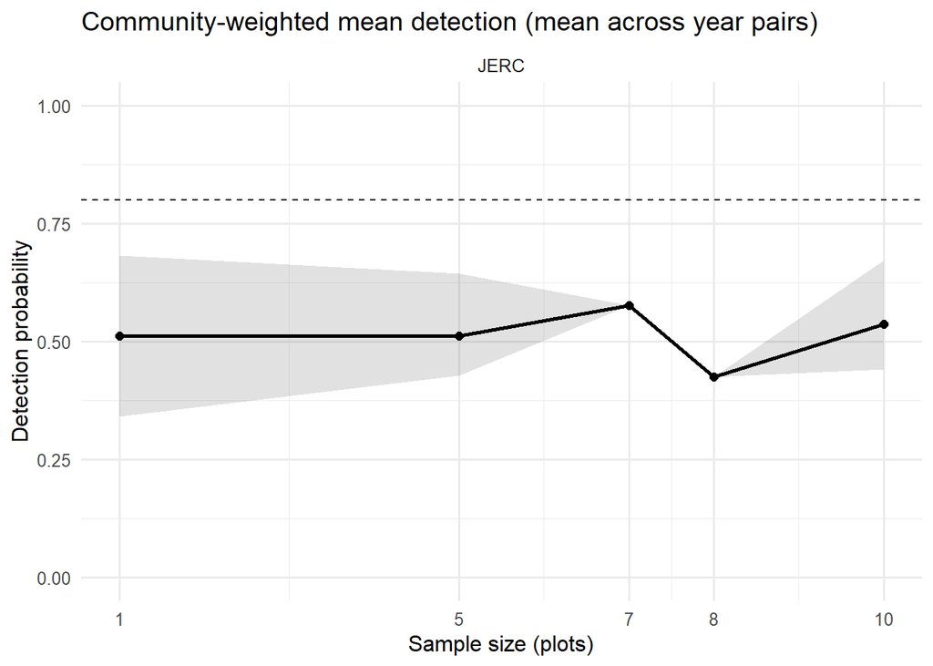

Figure 4.2: Figure A2. Mean community-weighted detection across year pairs for all sites (variable mode).